# hw2_Xuan_Huang

Xuan Huang

2022-10-04

```r
library(dplyr)
library(data.table)
library(tidyverse)
library(data.table)
library(gtools)
library(ggpmisc)
```

```r
library(graphics)
library(leaflet)
```

# Data Wrangling

```r
# download data
if (!file.exists("chs_individual.csv")) {
  download.file(
    url = "https://raw.githubusercontent.com/USCbiostats/data-science-data/master/01_chs/chs_individual.csv",
    destfile = "chs_individual.csv",
    method="libcurl",
    timeout = 60
    )
}
if (!file.exists("chs_regional.csv")) {
  download.file(
    url = "https://raw.githubusercontent.com/USCbiostats/data-science-data/master/01_chs/chs_regional.csv",
    destfile = "chs_regional.csv",
    method="libcurl",
    timeout = 60
    )
}
```

```r
# read data
chsInd <- fread("chs_individual.csv")
chsReg <- fread("chs_regional.csv")
head(chsInd)
```

```
##    sid  townname male race hispanic    agepft height weight      bmi asthma
## 1:   1 Lancaster    1    W        0 10.154689    123     54 16.22411      0
## 2:   2 Lancaster    1    W        0 10.461328    145     77 16.64685      0
## 3:   6 Lancaster    0    B        0 10.097194    145    143 30.91558      0
## 4:   7 Lancaster    0    O        0 10.746064    156     72 13.44809      0
## 5:   8 Lancaster    0    W        1  9.782341    132     61 15.91326      0
## 6:  10 Lancaster    1    O        1        NA     NA     NA       NA      0
##    active_asthma father_asthma mother_asthma wheeze hayfever allergy
## 1:             0             0             0      0        0       0
## 2:             0             0             0      1        0       0
## 3:             0             0             0      0        1       0
## 4:             0            NA             0      1        0       0
## 5:             0             1             0      1        1       1
## 6:             1             1             0      0        0       0
##    educ_parent smoke pets gasstove      fev      fvc     mmef
## 1:           3     0    1        1 1650.254 1800.005 2537.777
## 2:           5     0    1        0 2273.129 2721.111 2365.745
## 3:           2     0    0        1 2011.653 2257.244 1818.973
## 4:           2     1    1        1 1643.092 2060.526 1462.500
## 5:           3     0    1        0 1651.974 1996.382 1606.579
## 6:           1     0    1        1       NA       NA       NA
```

```r
head(chsReg)
```

```
##         townname pm25_mass pm25_so4 pm25_no3 pm25_nh4 pm25_oc pm25_ec pm25_om
## 1:        Alpine      8.74     1.73     1.59     0.88    2.54    0.48    3.04
## 2: Lake Elsinore     12.35     1.90     2.98     1.36    3.64    0.62    4.36
## 3:  Lake Gregory      7.66     1.07     2.07     0.91    2.46    0.40    2.96
## 4:     Lancaster      8.50     0.91     1.87     0.78    4.43    0.55    5.32
## 5:        Lompoc      5.96     1.08     0.73     0.41    1.45    0.13    1.74
## 6:    Long Beach     19.12     3.23     6.22     2.57    5.21    1.36    6.25
##    pm10_oc pm10_ec pm10_tc formic acetic  hcl hno3 o3_max o3106 o3_24   no2
## 1:    3.25    0.49    3.75   1.03   2.49 0.41 1.98  65.82 55.05 41.23 12.18
## 2:    4.66    0.63    5.29   1.18   3.56 0.46 2.63  66.70 54.42 32.23 17.03
## 3:    3.16    0.41    3.57   0.66   2.36 0.28 2.28  84.44 67.01 57.76  7.62
## 4:    5.68    0.56    8.61   0.88   2.88 0.22 1.80  54.81 43.88 32.86 15.77
## 5:    1.86    0.14    1.99   0.34   0.75 0.33 0.43  43.85 37.74 28.37  4.60
## 6:    6.68    1.39    8.07   1.57   2.94 0.73 2.67  39.44 28.22 18.22 33.11
##     pm10 no_24hr pm2_5_fr iacid oacid total_acids       lon      lat
## 1: 24.73    2.48    10.28  2.39  3.52        5.50 -116.7664 32.83505
## 2: 34.25    7.07    14.53  3.09  4.74        7.37 -117.3273 33.66808
## 3: 20.05      NA     9.01  2.56  3.02        5.30 -117.2752 34.24290
## 4: 25.04   12.68       NA  2.02  3.76        5.56 -118.1542 34.68678
## 5: 18.40    2.05       NA  0.76  1.09        1.52 -120.4579 34.63915
## 6: 38.41   36.76    22.23  3.40  4.51        7.18 -118.1937 33.77005
```

### 1. After merging the data, make sure you don’t have any duplicates by counting the number of rows. Make sure it matches.

```r
dim(chsInd)
```

```
## [1] 1200   23
```

```r
dim(chsReg)
```

```
## [1] 12 27
```

```r
chsMerge <- merge(
  x = chsInd,
  y = chsReg,
  by.x = "townname",
  by.y = "townname",
  all.x = T,
  all.y = F
)
dim(chsMerge)
```

```
## [1] 1200   49
```

```r
# After merging the data, the rows of merged dataset is equal to the rows of
# individual CHS dataset

# To make sure there is no duplicates
chsMerge <- unique(chsMerge)

# Impute data using the average within the variables “male” and “hispanic” for
# missing value
#summary(chsMerge)
chsMale_His <- chsMerge %>%
  filter(male == 1 & hispanic == 1)

chsMerge[is.na(agepft), agepft := round(mean(chsMale_His$agepft, na.rm = T), digits = 3)]
chsMerge[is.na(height), height := round(mean(chsMale_His$height, na.rm = T), digits = 0)]
chsMerge[is.na(weight), weight := round(mean(chsMale_His$weight, na.rm = T), digits = 0)]
chsMerge[is.na(bmi), bmi := round(mean(chsMale_His$bmi, na.rm = T), digits = 3)]
chsMerge[is.na(asthma), asthma := round(mean(chsMale_His$asthma, na.rm = T), 1)]
chsMerge[is.na(father_asthma), father_asthma := round(mean(chsMale_His$father_asthma, na.rm = T), 1)]
chsMerge[is.na(mother_asthma), mother_asthma := round(mean(chsMale_His$mother_asthma, na.rm = T), 1)]
chsMerge[is.na(wheeze), wheeze := round(mean(chsMale_His$wheeze, na.rm = T), 1)]
chsMerge[is.na(hayfever), hayfever := round(mean(chsMale_His$hayfever, na.rm = T), 1)]
chsMerge[is.na(allergy), allergy := round(mean(chsMale_His$allergy, na.rm = T), 1)]
chsMerge[is.na(educ_parent), educ_parent := round(mean(chsMale_His$educ_parent, na.rm = T), 1)]
chsMerge[is.na(smoke), smoke := round(mean(chsMale_His$smoke, na.rm = T), 1)]
chsMerge[is.na(gasstove), gasstove := round(mean(chsMale_His$gasstove, na.rm = T), 1)]
chsMerge[is.na(fev), fev := round(mean(chsMale_His$fev, na.rm = T), digits = 1)]
chsMerge[is.na(fvc), fvc := round(mean(chsMale_His$fvc, na.rm = T), 1)]
chsMerge[is.na(mmef), mmef := round(mean(chsMale_His$mmef, na.rm = T), digits = 1)]

#summary(chsMerge)
```

### 2. Create a new categorical variable named “obesity_level” using the BMI measurement

```r
# create categorical variable
chsMerge$obesity_level <- cut(chsMerge$bmi,
                              breaks = c(0, 14, 22, 24, Inf),
                              labels = c("underweight", "normal", "overweight", "obese")
                              )

# create a summary table for bmi level
chsMerge %>%
  group_by(obesity_level) %>%
  summarise(
    min = min(bmi),
    max = max(bmi),
    count = n()
  )
```

```
## # A tibble: 4 × 4
##   obesity_level   min   max count
##   <fct>         <dbl> <dbl> <int>
## 1 underweight    11.3  14.0    35
## 2 normal         14.0  22.0   975
## 3 overweight     22.0  24.0    87
## 4 obese          24.0  41.3   103
```

### 3. Create another categorical variable named “smoke_gas_exposure”

```r
#“smoke_gas_exposure”  summarizes “Second Hand Smoke” and “Gas Stove.”
summary(chsMerge$smoke)
```

```
##    Min. 1st Qu.  Median    Mean 3rd Qu.    Max.
##  0.0000  0.0000  0.0000  0.1583  0.0000  1.0000
```

```r
summary(chsMerge$gasstove)
```

```
##    Min. 1st Qu.  Median    Mean 3rd Qu.    Max.
##    0.00    1.00    1.00    0.76    1.00    1.00
```

```r
# there are 4 possible combination of second hand smoke status and gas stove status
chsMerge <-
  chsMerge %>%
  mutate(
    smoke_gas_exposure = case_when(
      smoke == 0 & gasstove == 0 ~ "neiher",
      smoke == 1 & gasstove == 0 ~ "only smoke",
      smoke == 0 & gasstove == 1 ~ "only gas stove",
      smoke == 1 & gasstove == 1 ~ "both"
    )
  )

table(chsMerge$smoke_gas_exposure)
```

```
##
##           both         neiher only gas stove     only smoke
##            151            249            761             39
```

### 4. Create four summary tables showing the average (or proportion, if binary) and sd of “Forced expiratory volume in 1 second (ml)” and asthma indicator by town, sex, obesity level, and “smoke_gas_exposure.”

```r
# summary table by town
chsMerge %>%
  group_by(townname) %>%
  summarise(
    count = n(),
    average_fev = mean(fev),
    sd_fev = sd(fev),
    prop_asthma = mean(asthma),
    sd_asthma = sd(asthma)
            )
```

```
## # A tibble: 12 × 6
##    townname      count average_fev sd_fev prop_asthma sd_asthma
##    <chr>         <int>       <dbl>  <dbl>       <dbl>     <dbl>
##  1 Alpine          100       2091.   291.        0.11     0.314
##  2 Atascadero      100       2081.   324.        0.25     0.435
##  3 Lake Elsinore   100       2047.   304.        0.12     0.327
##  4 Lake Gregory    100       2095.   319.        0.15     0.359
##  5 Lancaster       100       2017.   318.        0.16     0.368
##  6 Lompoc          100       2046.   351.        0.11     0.314
##  7 Long Beach      100       1993.   321.        0.13     0.338
##  8 Mira Loma       100       1994.   326.        0.15     0.359
##  9 Riverside       100       1998.   279.        0.11     0.314
## 10 San Dimas       100       2030.   319.        0.17     0.378
## 11 Santa Maria     100       2033.   313.        0.13     0.338
## 12 Upland          100       2035.   343.        0.12     0.327
```

```r
# summary table by sex
chsMerge %>%
  group_by(male) %>%
  summarise(
    count = n(),
    average_fev = mean(fev),
    sd_fev = sd(fev),
    prop_asthma = mean(asthma),
    sd_asthma = sd(asthma)
            )
```

```
## # A tibble: 2 × 6
##    male count average_fev sd_fev prop_asthma sd_asthma
##   <int> <int>       <dbl>  <dbl>       <dbl>     <dbl>
## 1     0   610       1974.   315.       0.118     0.323
## 2     1   590       2105.   308.       0.168     0.374
```

```r
# by obesity level
chsMerge %>%
  group_by(obesity_level) %>%
  summarise(
    count = n(),
    average_fev = mean(fev),
    sd_fev = sd(fev),
    prop_asthma = mean(asthma),
    sd_asthma = sd(asthma)
            )
```

```
## # A tibble: 4 × 6
##   obesity_level count average_fev sd_fev prop_asthma sd_asthma
##   <fct>         <int>       <dbl>  <dbl>       <dbl>     <dbl>
## 1 underweight      35       1699.   305.      0.0857     0.284
## 2 normal          975       2010.   296.      0.136      0.343
## 3 overweight       87       2224.   317.      0.161      0.370
## 4 obese           103       2268.   324.      0.204      0.405
```

```r
# by smoke_gas_exposure
chsMerge %>%
  group_by(smoke_gas_exposure) %>%
  summarise(
    count = n(),
    average_fev = mean(fev),
    sd_fev = sd(fev),
    prop_asthma = mean(asthma),
    sd_asthma = sd(asthma)
            )
```

```
## # A tibble: 4 × 6
##   smoke_gas_exposure count average_fev sd_fev prop_asthma sd_asthma
##   <chr>              <int>       <dbl>  <dbl>       <dbl>     <dbl>
## 1 both                 151       2029.   300.       0.126     0.333
## 2 neiher               249       2047.   333.       0.137     0.344
## 3 only gas stove       761       2034.   318.       0.147     0.355
## 4 only smoke            39       2093.   297.       0.154     0.366
```

# Looking at the Data (EDA)

### The primary questions of interest are:

- 1. What is the association between BMI and FEV (forced expiratory volume)? **People with a higher BMI level will have a higher forced expiratory volume.**
- 2. What is the association between smoke and gas exposure and FEV? **There is no clear association between smoke and gas exposure and FEV. People contact with only smoke exposure will have higher FEV.**
- 3. What is the association between PM2.5 exposure and FEV? **The average forced expiratory volume for people living in a given town will decrease with the increase of PM2.5 concentration.**

### EDA checklist

```r
# check the dimensions and headers and footers
dim(chsMerge)
```

```
## [1] 1200   51
```

```r
head(chsMerge)
```

```
##    townname sid male race hispanic    agepft height weight      bmi asthma
## 1:   Alpine 835    0    W        0 10.099932    143     69 15.33749      0
## 2:   Alpine 838    0    O        1  9.486653    133     62 15.93183      0
## 3:   Alpine 839    0    M        1 10.053388    142     86 19.38649      0
## 4:   Alpine 840    0    W        0  9.965777    146     78 16.63283      0
## 5:   Alpine 841    1    W        1 10.548939    150     78 15.75758      0
## 6:   Alpine 842    1    M        1  9.489391    139     65 15.29189      0
##    active_asthma father_asthma mother_asthma wheeze hayfever allergy
## 1:             0             0             0      0        0       1
## 2:             0             0             0      0        0       0
## 3:             0             0             1      1        1       1
## 4:             0             0             0      0        0       0
## 5:             0             0             0      0        0       0
## 6:             0             0             0      1        0       0
##    educ_parent smoke pets gasstove      fev      fvc     mmef pm25_mass
```

[output cut: 27 more lines]

```r
tail(chsMerge)
```

```
##    townname  sid male race hispanic    agepft height weight      bmi asthma
## 1:   Upland 1866    0    O        1  9.806982    139     60 14.11559      0
## 2:   Upland 1867    0    M        1  9.618070    140     71 16.46568      0
## 3:   Upland 2031    1    W        0  9.798768    135     83 20.70084      0
## 4:   Upland 2032    1    W        0  9.549624    137     59 14.28855      0
## 5:   Upland 2033    0    M        0 10.121834    130     67 18.02044      0
## 6:   Upland 2053    0    W        0  9.967000    139     83 19.41100      0
##    active_asthma father_asthma mother_asthma wheeze hayfever allergy
## 1:             0             0             0      0        0       0
## 2:             0             1             0      0        0       0
## 3:             0             0             0      1        0       1
## 4:             0             0             1      1        1       1
## 5:             1             0             0      1        1       0
## 6:             0             0             0      0        0       0
##    educ_parent smoke pets gasstove      fev      fvc     mmef pm25_mass
```

[output cut: 27 more lines]

```r
#check the variable types
str(chsMerge)
```

```
## Classes 'data.table' and 'data.frame':   1200 obs. of  51 variables:
##  $ townname          : chr  "Alpine" "Alpine" "Alpine" "Alpine" ...
##  $ sid               : int  835 838 839 840 841 842 843 844 847 849 ...
##  $ male              : int  0 0 0 0 1 1 1 1 1 1 ...
##  $ race              : chr  "W" "O" "M" "W" ...
##  $ hispanic          : int  0 1 1 0 1 1 0 1 0 0 ...
##  $ agepft            : num  10.1 9.49 10.05 9.97 10.55 ...
##  $ height            : int  143 133 142 146 150 139 149 143 137 147 ...
##  $ weight            : int  69 62 86 78 78 65 98 65 69 112 ...
##  $ bmi               : num  15.3 15.9 19.4 16.6 15.8 ...
##  $ asthma            : int  0 0 0 0 0 0 0 0 0 0 ...
##  $ active_asthma     : int  0 0 0 0 0 0 0 0 0 0 ...
##  $ father_asthma     : int  0 0 0 0 0 0 0 0 0 1 ...
##  $ mother_asthma     : int  0 0 1 0 0 0 0 0 0 0 ...
##  $ wheeze            : int  0 0 1 0 0 1 1 0 0 1 ...
```

[output cut: 39 more lines]

```r
# Take a closer look at some/all of the variables
# here, our key variables are bmi, fev, smoke_gas_exposure, PM2.5
summary(chsMerge$bmi)
```

```
##    Min. 1st Qu.  Median    Mean 3rd Qu.    Max.
##   11.30   15.96   17.81   18.57   19.99   41.27
```

```r
summary(chsMerge$fev)
```

```
##    Min. 1st Qu.  Median    Mean 3rd Qu.    Max.
##   984.8  1827.6  2060.1  2038.3  2223.6  3323.7
```

```r
table(chsMerge$smoke_gas_exposure)
```

```
##
##           both         neiher only gas stove     only smoke
##            151            249            761             39
```

```r
summary(chsMerge$pm25_mass)
```

```
##    Min. 1st Qu.  Median    Mean 3rd Qu.    Max.
##   5.960   7.615  10.545  14.362  20.988  29.970
```

**After taking a closer look of key variables, there is no unreasonable value of key variables. So we don’t need to clean our data.**

### 1. Facet plot showing scatterplots with regression lines of BMI vs FEV by “townname”.

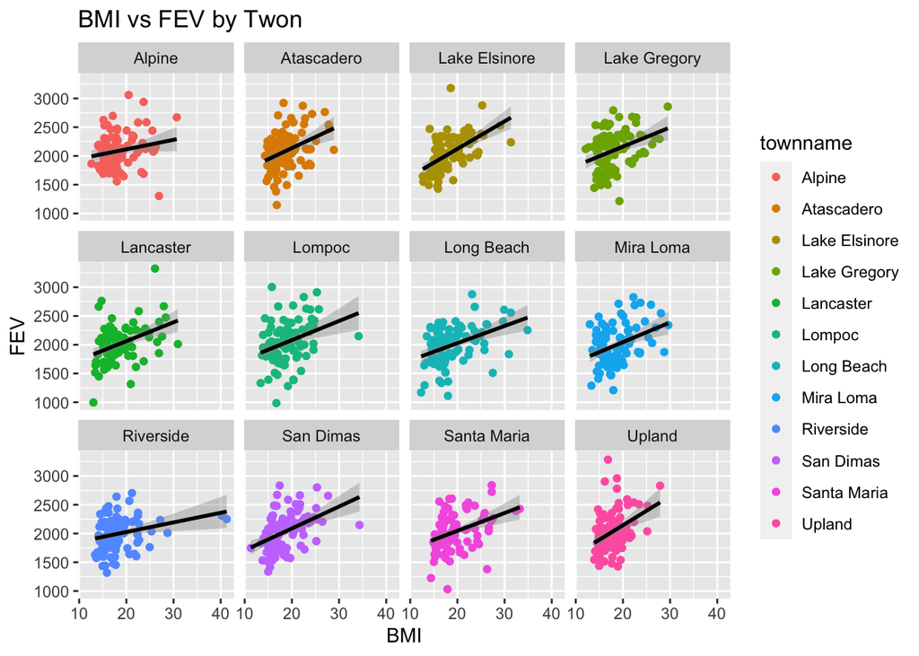

```r
chsMerge %>%
  ggplot(mapping = aes(x = bmi, y = fev, color = townname)) +
  geom_point() +
  geom_smooth(method = "lm", color = "Black") +
  labs(title = "BMI vs FEV by Twon",x = "BMI", y = "FEV") +
  facet_wrap(~ townname)
```

**As shown of these scatter plots, there is a positive relationship between BMI and FEV. With the increasing of BMI, forced expiratory volume also increased. For the different towns, this correlation can be strong or weak. So we can speculate that the correlation between BMI and FEV can vary by towns.**

### 2. Stacked histograms of FEV by BMI category and FEV by smoke/gas exposure. Use different color schemes than the ggplot default.

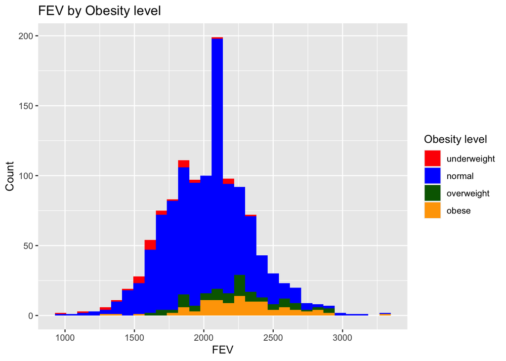

```r
# Stacked histograms of FEV by BMI category
chsMerge %>%
  ggplot(aes(x = fev, fill = obesity_level)) +
  geom_histogram() +
  scale_fill_manual(values = c("red", "blue", "darkgreen", "orange")) +
  labs(title = "FEV by Obesity level",x = "FEV", y = "Count", fill = "Obesity level")
```

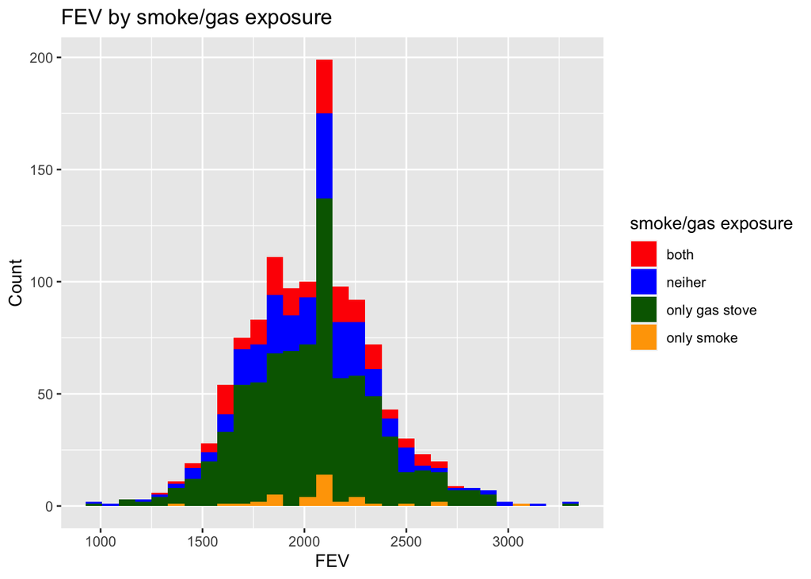

```r
# FEV by smoke/gas exposure
chsMerge %>%
  ggplot(aes(x = fev, fill = smoke_gas_exposure)) +
  geom_histogram() +
  scale_fill_manual(values = c("red", "blue", "darkgreen", "orange")) +
  labs(title = "FEV by smoke/gas exposure", x = "FEV", y = "Count", fill = "smoke/gas exposure")
```

### 3. Barchart of BMI by smoke/gas exposure.

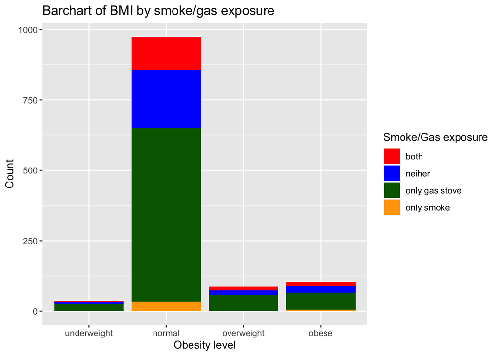

```r
chsMerge %>%
  ggplot(aes(x = obesity_level, fill = smoke_gas_exposure)) +
  geom_bar() +
  scale_fill_manual(values = c("red", "blue", "darkgreen", "orange")) +
  labs(title = "Barchart of BMI by smoke/gas exposure", x = "Obesity level", y = "Count", fill = "Smoke/Gas exposure")
```

### 4. Statistical summary graphs of FEV by BMI and FEV by smoke/gas exposure category.

```
## No summary function supplied, defaulting to `mean_se()`
```

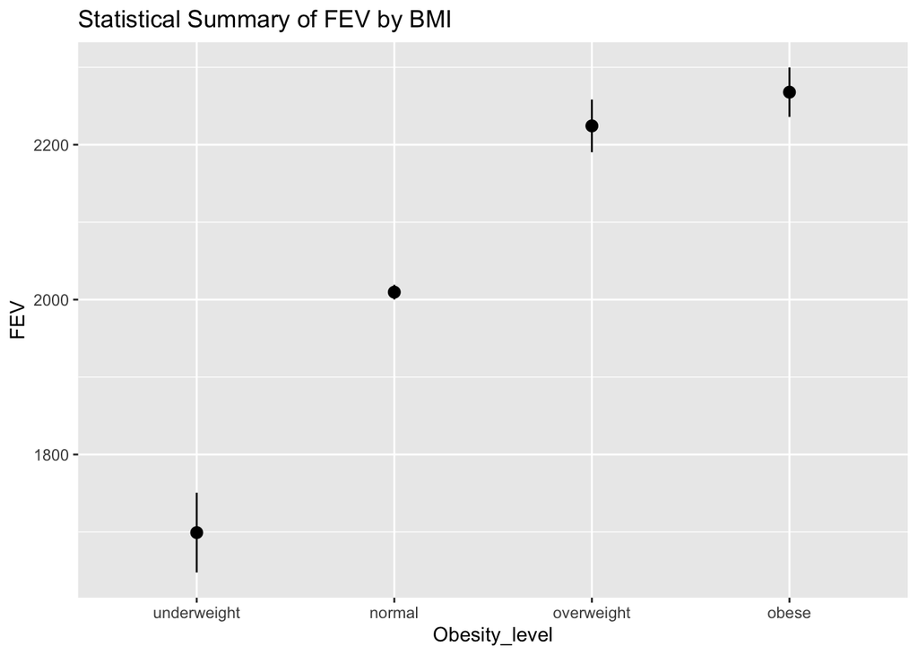

```r
chsMerge %>%
  ggplot(mapping = aes(y = fev, x = obesity_level),
         fun = median,
         fun.min = min,
         fun.max = max
         ) +
  stat_summary() +
  labs(title = "Statistical Summary of FEV by BMI", y = "FEV", x = "Obesity_level")
```

```
## No summary function supplied, defaulting to `mean_se()`
```

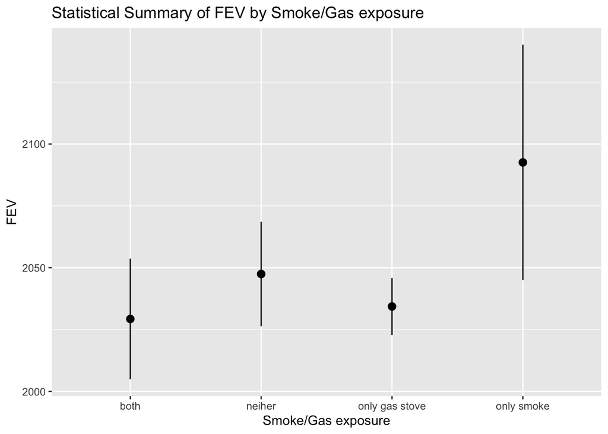

```r
chsMerge %>%
  ggplot(mapping = aes(y = fev, x = smoke_gas_exposure),
         fun = median,
         fun.min = min,
         fun.max = max
         ) +
  stat_summary() +
  labs(title = "Statistical Summary of FEV by Smoke/Gas exposure", y = "FEV", x = "Smoke/Gas exposure")
```

**The statistical summary graph of FEV by BMI shown that with the increase of BMI level, people’s average FEV value increase. Obese people have the most forced expiratory volume.**

### 5. A leaflet map showing the concentrations of PM2.5 mass in each of the CHS communities.

```r
temp.pal <- colorFactor(palette ='viridis', domain = chsMerge$pm25_mass)

leaflet(chsMerge[!is.na(pm25_mass)]) %>%
  addProviderTiles('CartoDB.Positron') %>%
  addCircles(
    lat = ~lat, lng=~lon,
    label = chsMerge$townname, color = ~ temp.pal(pm25_mass),
    opacity = 1, fillOpacity = 1, radius = 500
    ) %>%
  # And a pretty legend
  addLegend('bottomleft', pal=temp.pal, values = chsMerge$pm25_mass,
          title='Concentrations of PM2.5 mass in each of the CHS communities', opacity=1)
```

[interactive chart not shown]

### 6. Choose a visualization to examine whether PM2.5 mass is associated with FEV.

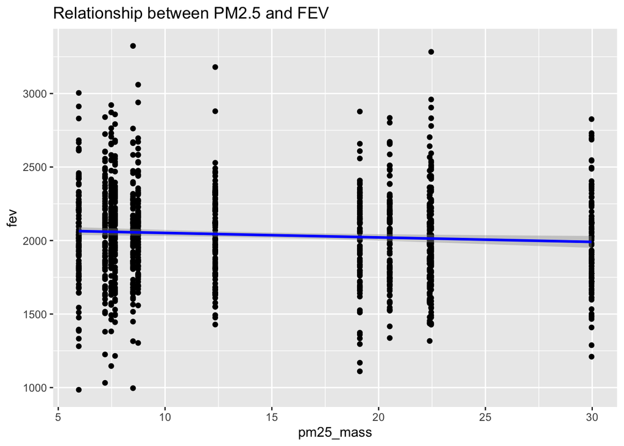

```r
# Both PM2.5 and FEV are numeric variable, so we can create a scatter plot with a linear regression model
chsMerge %>%
  ggplot(mapping = aes(x = pm25_mass, y = fev)) +
  geom_point() +
  geom_smooth(method = "lm", color = "blue") +
  labs(title = "Relationship between PM2.5 and FEV")
```

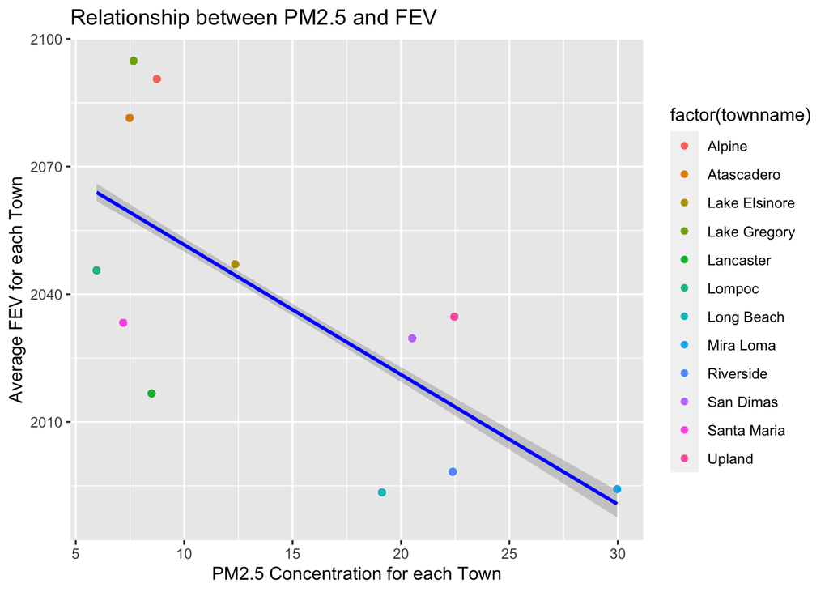

```r
# Based on the previous scatter plot, we cannot find a obviously association.
# Because PM2.5 mass is a town_level variable, we should calculate the typical
# FEV for each town and research the relationship between the town level FEV and
# twon level PM2.5 mass

chsMerge_town <- chsMerge %>%
  group_by(townname) %>%
  mutate(fev_town = mean(fev))

chsMerge_town %>%
  ggplot(mapping = aes(x = pm25_mass, y = fev_town, color = factor(townname))) +
  geom_point() +
  geom_smooth(method = "lm", color = "blue") +
  labs(title = "Relationship between PM2.5 and FEV", x = "PM2.5 Concentration for each Town", y = "Average FEV for each Town")
```

**Based on the linear regression model, the average forced expiratory volume for people living in a given town will decrease with the increase of PM2.5 concentration.**

### The primary questions of interest are:

- 1. What is the association between BMI and FEV (forced expiratory volume)? **People with a higher BMI level will have a higher forced expiratory volume.**
- 2. What is the association between smoke and gas exposure and FEV? **There is no clear association between smoke and gas exposure and FEV. People contact with only smoke exposure will have higher FEV.**
- 3. What is the association between PM2.5 exposure and FEV? **The average forced expiratory volume for people living in a given town will decrease with the increase of PM2.5 concentration.**